# Practical Machine Learning Assignment

## Introduction

The objective of this exercise is to predict the manner in which six participants performed some exercises. The dataset contains data from accelerometers on the belt, forearm, arm, and dumbbell of the six participants. They were asked to perform barbell lifts correctly and incorrectly in five different ways.

Six young health participants were asked to perform one set of 10 repetitions of the Unilateral Dumbbell Biceps Curl in five different fashions: exactly according to the specification (Class A), throwing the elbows to the front (Class B), lifting the dumbbell only halfway (Class C), lowering the dumbbell only halfway (Class D) and throwing the hips to the front (Class E).

Class A corresponds to the specified execution of the exercise, while the other 4 classes correspond to common mistakes. Participants were supervised by an experienced weight lifter to make sure the execution complied to the manner they were supposed to simulate. The exercises were performed by six male participants aged between 20-28 years, with little weight lifting experience. We made sure that all participants could easily simulate the mistakes in a safe and controlled manner by using a relatively light dumbbell (1.25kg).

## Loading the Data

```r
# load url for datasets
UrlTrain <- "http://d396qusza40orc.cloudfront.net/predmachlearn/pml-training.csv"
UrlTest <- "http://d396qusza40orc.cloudfront.net/predmachlearn/pml-testing.csv"
training <- read.csv(url(UrlTrain))
testing <- read.csv(url(UrlTest))
```

## Loading Required Packages and Preparing the Data

```r
# load packages
library(caret)
```

```r
library(corrplot)
library(dplyr)
library(gbm)
library(knitr)
library(randomForest)
library(rattle)
library(rpart)
library(rpart.plot)
# create data partition
set.seed(11111)
inTrain <- createDataPartition(training$classe, p=0.7, list=FALSE)
TrainSet <- training[inTrain,]
TestSet <- training[-inTrain,]
dim(TrainSet)
```

```
## [1] 13737   160
```

```r
dim(TestSet)
```

```
## [1] 5885  160
```

## Data Cleaning

```r
# remove 'near zero variance' variables (columns)
nzv <- nearZeroVar(TrainSet)
TrainSet <- TrainSet[,-nzv]
TestSet <- TestSet[,-nzv]
dim(TrainSet)
```

```
## [1] 13737   105
```

```r
dim(TestSet)
```

```
## [1] 5885  105
```

```r
# remove variables (columns) with majority 'NA' data
mostNA <- sapply(TrainSet, function(x) mean(is.na(x))) > 0.95
TrainSet <- TrainSet[,mostNA==FALSE]
TestSet <- TestSet[,mostNA==FALSE]
dim(TrainSet)
```

```
## [1] 13737    59
```

```r
dim(TestSet)
```

```
## [1] 5885   59
```

```r
# remove identifiers
TrainSet <- TrainSet[,-(1:5)]
TestSet <- TestSet[,-(1:5)]
dim(TrainSet)
```

```
## [1] 13737    54
```

```r
dim(TestSet)
```

```
## [1] 5885   54
```

## Exploratory Data Analysis - Correlational Matrix

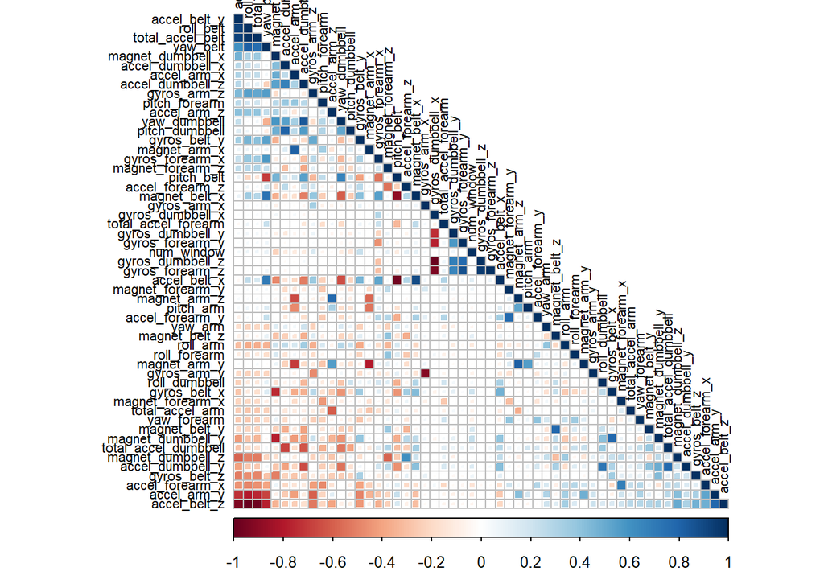

```r
corMatrix <- cor(TrainSet[,-54])
corrplot(corMatrix, order = "FPC", method = "square", type = "lower",
         tl.cex = 0.7, tl.col = "black", tl.pos = "ld")
```

From the correlation matrix, we can see the highly correlated variables as the darker colours.

## Prediction Model Building

We will attempt a total of three prediction models and select the one with highest accuracy value for the quiz predictions. The three models selected are: 1. Random Forests 2. Decision Tree 3. Generalised Boosted Model

### 1. Random Forest

```r
set.seed(11111)
RFcontrol <- trainControl(method = "cv", number = 3, verboseIter = FALSE)
RFmodel <- train(classe ~ ., data = TrainSet, method = "rf", trControl = RFcontrol)
RFmodel$finalModel
```

```
##
## Call:
##  randomForest(x = x, y = y, mtry = param$mtry)
##                Type of random forest: classification
##                      Number of trees: 500
## No. of variables tried at each split: 27
##
##         OOB estimate of  error rate: 0.25%
## Confusion matrix:
##      A    B    C    D    E  class.error
## A 3904    1    0    0    1 0.0005120328
## B    6 2649    2    1    0 0.0033860045
## C    0    8 2388    0    0 0.0033388982
## D    0    0    8 2244    0 0.0035523979
## E    0    0    0    8 2517 0.0031683168
```

```r
# predict on test set
RFpredict <- predict(RFmodel, newdata = TestSet)
RFmatrix <- confusionMatrix(RFpredict, TestSet$classe)
RFmatrix
```

```
## Confusion Matrix and Statistics
##
##           Reference
## Prediction    A    B    C    D    E
##          A 1674    7    0    0    0
##          B    0 1132    5    0    0
##          C    0    0 1021    1    0
##          D    0    0    0  963    4
##          E    0    0    0    0 1078
##
## Overall Statistics
##
##                Accuracy : 0.9971
##                  95% CI : (0.9954, 0.9983)
##     No Information Rate : 0.2845
##     P-Value [Acc > NIR] : < 2.2e-16
##
##                   Kappa : 0.9963
##
##  Mcnemar's Test P-Value : NA
##
## Statistics by Class:
##
##                      Class: A Class: B Class: C Class: D Class: E
## Sensitivity            1.0000   0.9939   0.9951   0.9990   0.9963
## Specificity            0.9983   0.9989   0.9998   0.9992   1.0000
## Pos Pred Value         0.9958   0.9956   0.9990   0.9959   1.0000
## Neg Pred Value         1.0000   0.9985   0.9990   0.9998   0.9992
## Prevalence             0.2845   0.1935   0.1743   0.1638   0.1839
## Detection Rate         0.2845   0.1924   0.1735   0.1636   0.1832
## Detection Prevalence   0.2856   0.1932   0.1737   0.1643   0.1832
## Balanced Accuracy      0.9992   0.9964   0.9975   0.9991   0.9982
```

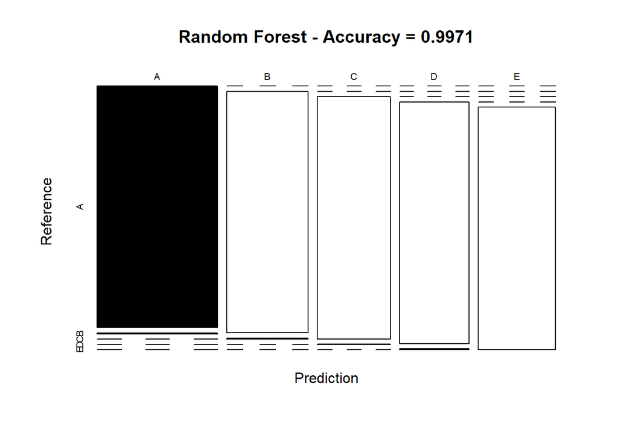

```r
# plot results
plot(RFmatrix$table, col = RFmatrix$byClass,
     main = paste("Random Forest - Accuracy =",
                  round(RFmatrix$overall['Accuracy'], 4)))
```

### 2. Decision Tree

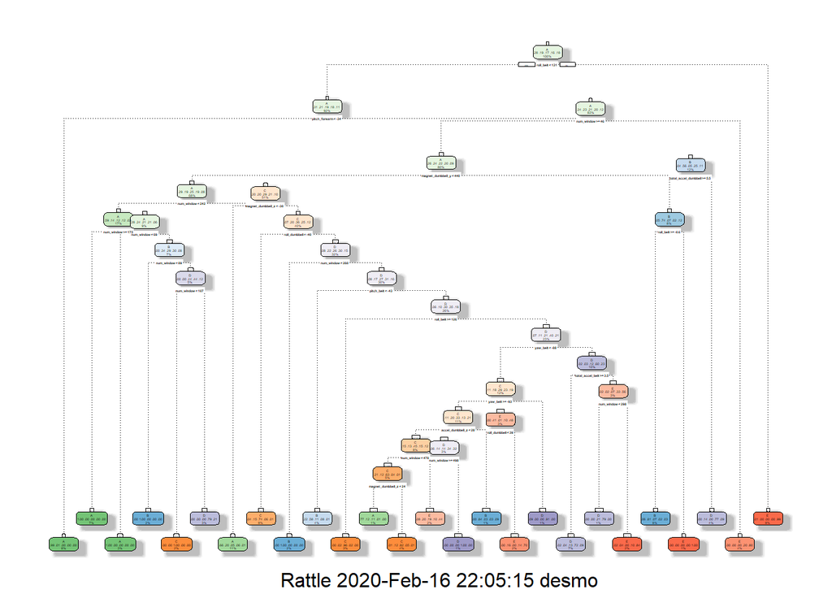

```r
set.seed(11111)
DTmodel <- rpart(classe ~ ., data = TrainSet, method = "class")
fancyRpartPlot(DTmodel)
```

```r
# predict on test set
DTpredict <- predict(DTmodel, newdata = TestSet, type = "class")
DTmatrix <- confusionMatrix(DTpredict, TestSet$classe)
DTmatrix
```

```
## Confusion Matrix and Statistics
##
##           Reference
## Prediction    A    B    C    D    E
##          A 1523  178   48   43   12
##          B   89  768   60   29   27
##          C   19   86  814   47    6
##          D   25   59   69  766   99
##          E   18   48   35   79  938
##
## Overall Statistics
##
##                Accuracy : 0.8172
##                  95% CI : (0.807, 0.827)
##     No Information Rate : 0.2845
##     P-Value [Acc > NIR] : < 2.2e-16
##
##                   Kappa : 0.7682
##
##  Mcnemar's Test P-Value : 3.672e-16
##
## Statistics by Class:
##
##                      Class: A Class: B Class: C Class: D Class: E
## Sensitivity            0.9098   0.6743   0.7934   0.7946   0.8669
## Specificity            0.9333   0.9568   0.9675   0.9488   0.9625
## Pos Pred Value         0.8442   0.7893   0.8374   0.7525   0.8390
## Neg Pred Value         0.9630   0.9245   0.9568   0.9593   0.9698
## Prevalence             0.2845   0.1935   0.1743   0.1638   0.1839
## Detection Rate         0.2588   0.1305   0.1383   0.1302   0.1594
## Detection Prevalence   0.3065   0.1653   0.1652   0.1730   0.1900
## Balanced Accuracy      0.9215   0.8155   0.8804   0.8717   0.9147
```

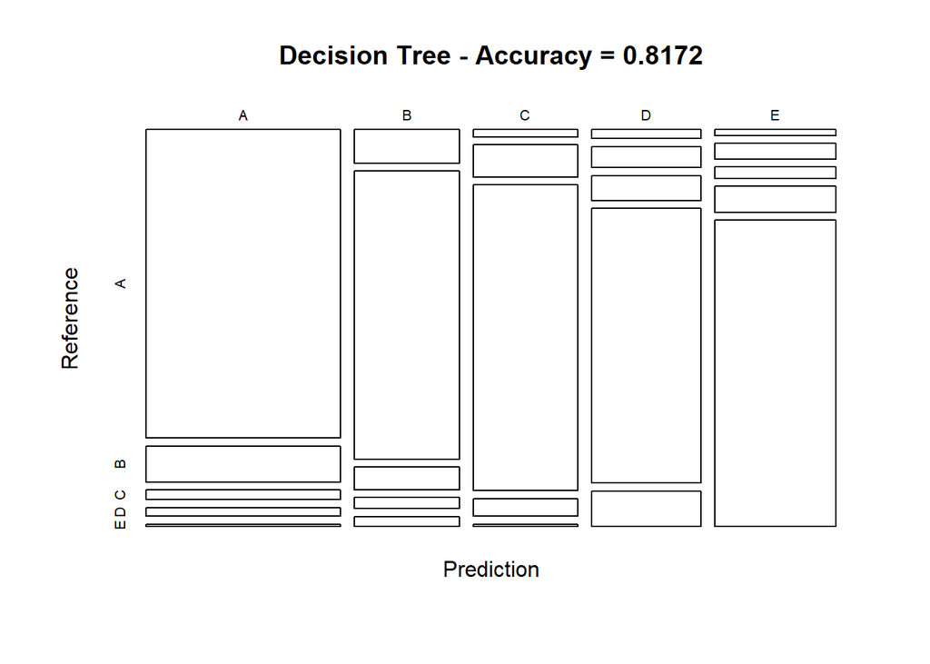

```r
# plot results
plot(DTmatrix$table, col = DTmatrix$byClass,
     main = paste("Decision Tree - Accuracy =",
                  round(DTmatrix$overall['Accuracy'], 4)))
```

### 3. Generalised Boosted Model

```r
set.seed(11111)
GBcontrol <- trainControl(method = "repeatedcv", number = 5, repeats = 1)
GBmodel <- train(classe ~ ., data = TrainSet, method = "gbm",
                 trControl = GBcontrol, verbose = FALSE)
GBmodel$finalModel
```

```
## A gradient boosted model with multinomial loss function.
## 150 iterations were performed.
## There were 53 predictors of which 53 had non-zero influence.
```

```r
# predict on test set
GBpredict <- predict(GBmodel, newdata = TestSet)
GBmatrix <- confusionMatrix(GBpredict, TestSet$classe)
GBmatrix
```

```
## Confusion Matrix and Statistics
##
##           Reference
## Prediction    A    B    C    D    E
##          A 1667   18    0    0    0
##          B    6 1104    6    6    8
##          C    0   14 1018    8    2
##          D    1    2    2  948   14
##          E    0    1    0    2 1058
##
## Overall Statistics
##
##                Accuracy : 0.9847
##                  95% CI : (0.9812, 0.9877)
##     No Information Rate : 0.2845
##     P-Value [Acc > NIR] : < 2.2e-16
##
##                   Kappa : 0.9807
##
##  Mcnemar's Test P-Value : NA
##
## Statistics by Class:
##
##                      Class: A Class: B Class: C Class: D Class: E
## Sensitivity            0.9958   0.9693   0.9922   0.9834   0.9778
## Specificity            0.9957   0.9945   0.9951   0.9961   0.9994
## Pos Pred Value         0.9893   0.9770   0.9770   0.9804   0.9972
## Neg Pred Value         0.9983   0.9926   0.9983   0.9967   0.9950
## Prevalence             0.2845   0.1935   0.1743   0.1638   0.1839
## Detection Rate         0.2833   0.1876   0.1730   0.1611   0.1798
## Detection Prevalence   0.2863   0.1920   0.1771   0.1643   0.1803
## Balanced Accuracy      0.9958   0.9819   0.9936   0.9898   0.9886
```

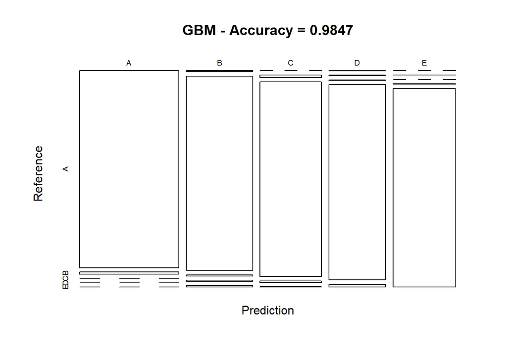

```r
# plot results
plot(GBmatrix$table, col = GBmatrix$byClass,
     main = paste("GBM - Accuracy =",
                  round(GBmatrix$overall['Accuracy'], 4)))
```

## Applying Selected Model to Predict the 20 Test Cases

Since the Random Forest model gave the highest accuracy value, we will use it to apply to the 20 test cases.

```r
TESTpredict <- predict(RFmodel, newdata = testing)
TESTpredict
```

```
##  [1] B A B A A E D B A A B C B A E E A B B B
## Levels: A B C D E
```

```r
# add prediction to dataframe
NEWtesting <- testing %>% mutate(predicted_classe = TESTpredict)
```

### Acknowledgements

The dataset was generously provided from the following source: Velloso, E.; Bulling, A.; Gellersen, H.; Ugulino, W.; Fuks, H. “Qualitative Activity Recognition of Weight Lifting Exercises. Proceedings of 4th International Conference in Cooperation with SIGCHI (Augmented Human ’13)”. Stuttgart, Germany: ACM SIGCHI, 2013.